# EXAM 1

Chan, Kim Fai

10/18/2021

setwd(“~/Desktop/jeff’s documents/Master of Economics in CCNY/ECONOMETRICS ECO B2000/EXAM 1”) load(“Household_Pulse_data_v2.RData”) attach(Household_Pulse_data) summary(Household_Pulse_data)

#1 xtabs(~ EEDUC + RECVDVACC + REGION)

northeast <- (REGION == “northeast”) & (RECVDVACC == “yes got vaxx”) & (EEDUC == “SOME COLL”) rnorm(northeast) y = rnorm(REGION == “northeast”) summary(northeast) x = rnorm(RECVDVACC == “yes got vaxx”)

t.test(x,y)

#2 #Anova test Anova_var<- ((REGION == “West”) & (RECVDVACC == “yes got vaxx”) & (EEDUC == “assoc deg”) & (GENID_DESCRIBE == “Female”)) x = (REGION == “West”) x1 = (RECVDVACC == “yes got vaxx”) y = (EEDUC == “assoc deg”) y1 = (GENID_DESCRIBE == “Female”)

#3 ######METHOD ONE: #LET ME TRY MAKE REGRESSION IN A SET OF VARIOUBLE TO SEE HOW SIGNIFICANT BETWEEN MULTIPLE VARIABLE AND INCOME: Household_Pulse_data$REGION <- factor(Household_Pulse_data$REGION) Household_Pulse_data$ANXIOUS <- as.numeric(Household_Pulse_data$ANXIOUS) Household_Pulse_data$EEDUC <- as.numeric(Household_Pulse_data$EEDUC) Household_Pulse_data$EGENID_BIRTH <- as.numeric(Household_Pulse_data$EGENID_BIRTH) Household_Pulse_data$RRACE <- as.numeric(Household_Pulse_data$RRACE) Household_Pulse_data$REGION <- as.numeric(Household_Pulse_data$REGION) Household_Pulse_data$INCOME <- as.numeric(Household_Pulse_data$INCOME)

TOTAL <- lm(INCOME ~ `EEDUC` + EGENID_BIRTH + `RRACE` + ANXIOUS + `REGION`, Household_Pulse_data) summary(TOTAL)

#LET’S SEE STEP REGRESSION: step(TOTAL) #WE COULD DELETE SOME LOWER NUMBER IN AIC VARIOUABLE

#LET ME SEE MORE DETAILS ABOUT EEDUC AND ANXIOUS: #TRY ANXIOUS AND INCOME: Household_Pulse_data$ANXIOUS <- as.numeric(Household_Pulse_data$ANXIOUS) mlr <- lm(ANXIOUS ~ `INCOME`, Household_Pulse_data) summary(mlr)

par(mfrow = c(1, 2)) plot(Household_Pulse_data$ANXIOUS, Household_Pulse_data$INCOME)

#THEN TRY EEDUC AND INCOME: Household_Pulse_data$EEDUC <- as.numeric(Household_Pulse_data$EEDUC) EEDUC_INCOME <- lm(EEDUC ~ `INCOME`, Household_Pulse_data) summary(EEDUC_INCOME) par(mfrow = c(1, 2)) plot(Household_Pulse_data$EEDUC, Household_Pulse_data$INCOME)

#I DECIDE TO JUST APPLY EEDUC AND ANXIOUS AND REMOVE VARIOUABLE REGION, RRACE AND GENDER. Household_Pulse_data$ANXIOUS <- as.numeric(Household_Pulse_data$ANXIOUS) Household_Pulse_data$EEDUC <- as.numeric(Household_Pulse_data$EEDUC) Household_Pulse_data$INCOME <- as.numeric(Household_Pulse_data$INCOME)

NEW_TOTAL <- lm(INCOME ~ `EEDUC` + ANXIOUS, Household_Pulse_data) summary(TOTAL) plot(NEW_TOTAL, 2) detach()

[output not shown]

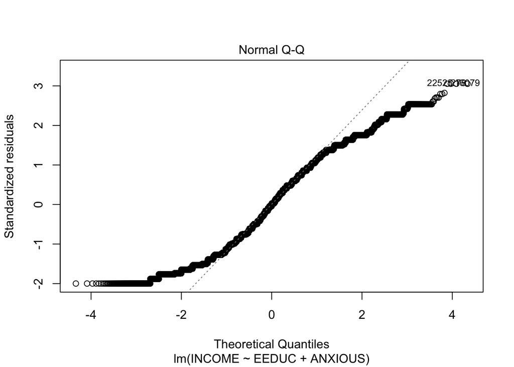

[output not shown]

```
##  R package version 5.2.2. https://CRAN.R-project.org/package=stargazer
```

```
##
## ================================================
##                         Dependent variable:
##                     ----------------------------
##                                INCOME
## ------------------------------------------------
## EEDUC                         0.577***
##                               (0.006)
##
## ANXIOUS                       0.259***
##                               (0.007)
##
## Constant                      0.114***
##                               (0.037)
##
## ------------------------------------------------
## Observations                   69,114
## R2                             0.139
## Adjusted R2                    0.139
## Residual Std. Error      2.224 (df = 69111)
## F Statistic         5,580.747*** (df = 2; 69111)
## ================================================
## Note:                *p<0.1; **p<0.05; ***p<0.01
```

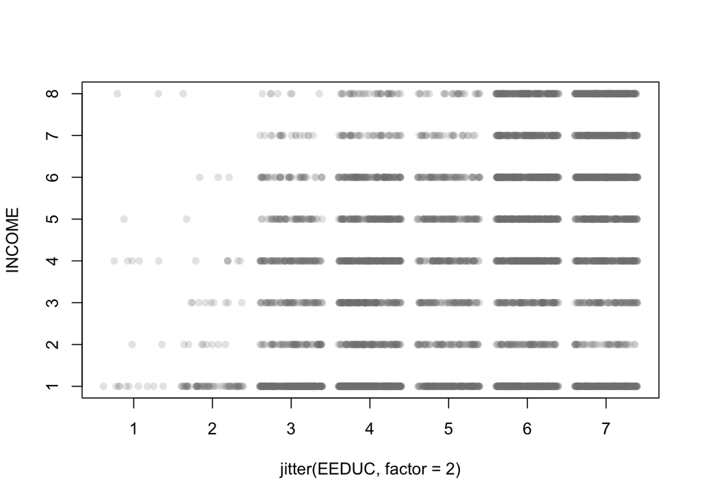

[figure not shown]

```r
detach()
```

#CONCLUSION: I CREATE A STEP FUNCTION TO DETERMINE WHICH VARIABLE IS KEY INPORTANT TO INCOME. WE FOUND THAT THE EDUCTION LEVEL IS SIGNIFICANT VARIABLE TO INCOME. AND INCOME LEVEL CASUE ANXIOUS LEVEL INCREASE, WHICH WITH A POSITIVE RELATIONSHIP. AND SEEMS REGION DOESN’T HAVE TOO MUCH IMPACT TO INCOME.